# Prosa

22/8/2020

## Analisi sul mondo del lavoro, nell’ambito dell’IT

## Introduzione

Andremo ad analizzare le opportunità lavorative che il mondo offre a noi amanti dell’informatica e di tutto ciò che gli ruota attorno.

Per fare ciò andremo ad usare un dataset contenente annunci di lavoro presi dal portale Glassdoor, uno dei pilastri in questo settore. Fondato nel Giugno 2007 in California, in un futuro sarebbe carino analizzare la California, terra che ha visto nascere le più importanti realtà nell’ambito IT, sarà l’acqua che bevono.

## Avendo i dati per capire, per quanto sia fattibile, il mondo del lavoro, cosa vorremo sapere?

Dato che il lavoro, è una parte fondamentale della nostra vita, l’unica risposta plausibile a questa domanda è: tutto il possibile. Questo forse è il modo peggiore per porsi domande, perche se si vuole fare un’analisi con la premessa di voler sapere tutto, senza individuare uno schema che ci porti più risposte possibile, non otteniamo nulla. Quindi proviamo a fare un percorso tale che ci permette di trovare risposte utili per costruire la nostra carriera. Iniziamo!

## Per dove compriamo il biglietto dell’aereo? (Mi raccomando, visti i tempi, fate l’assicurazione per il rimborso).

Cerchiamo quali sono le 3 città con più opportunità lavorative:

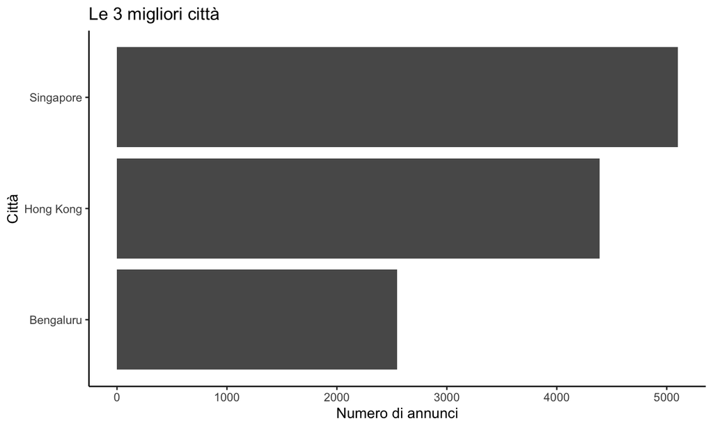

```r
jobs_listings_top_four_cities <- jobs_listings %>%
  group_by(header.location) %>%
  dplyr::summarise(count = n(), .groups = 'drop') %>%
  arrange(desc(count)) %>%
  slice(1:3)

theme_set(theme_classic())
ggplot(jobs_listings_top_four_cities,
       aes(x=header.location, y=count)) +
  geom_bar(stat = "identity") +
  labs(title = "Le 3 migliori città",
       y="Numero di annunci",
       x= "Città") +
  coord_flip()
```

A quanto pare: Singapore, Hong Kong e Bengaluru sono le città con più opportunità lavorative.  
Vi piacciono? A me sinceramente no, proviamo ad essere più specifici.

## Io voglio lavorare come data analyst, vediamo se sono più fortunato con la geografia.

Vediamo le 3 città con più opportunità per lavorare come: data analyst.

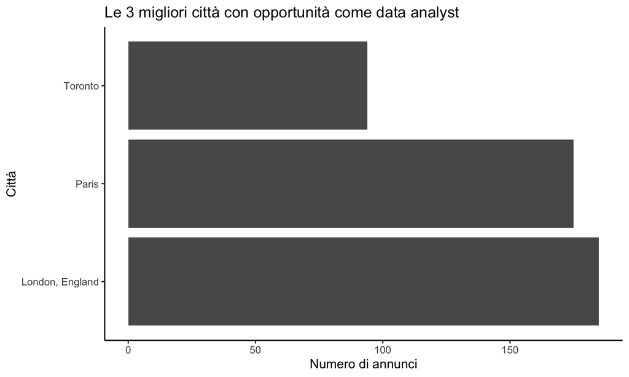

```r
jobs_for_data_science <- jobs_listings %>%
  filter(str_detect(header.normalizedJobTitle, "data analyst"))

top_four_cities_for_data_science  <- jobs_for_data_science %>%
  group_by(header.location) %>%
  dplyr::summarise(count = n(), .groups = 'drop') %>%
  arrange(desc(count)) %>%
  slice(1:3)

ggplot(top_four_cities_for_data_science,
       aes(x=header.location, y=count)) +
  geom_bar(stat = "identity") +
  labs(
    title = "Le 3 migliori città con opportunità come data analyst",
      y="Numero di annunci",
    x= "Città") +
  coord_flip()
```

A quanto pare, Londra è la meta migliore, città interessante e sempre in movimento. Proviamo ad analizzare il mercato mondiale sotto altri aspetti, per poi capire meglio la situazione inglese.

## Sono curioso, chi offre più opportunità al mondo?

Cerchiamo di capire quali sonno le 3 aziende con più annunci, scommetto che Amazon figurerà fra queste 3.

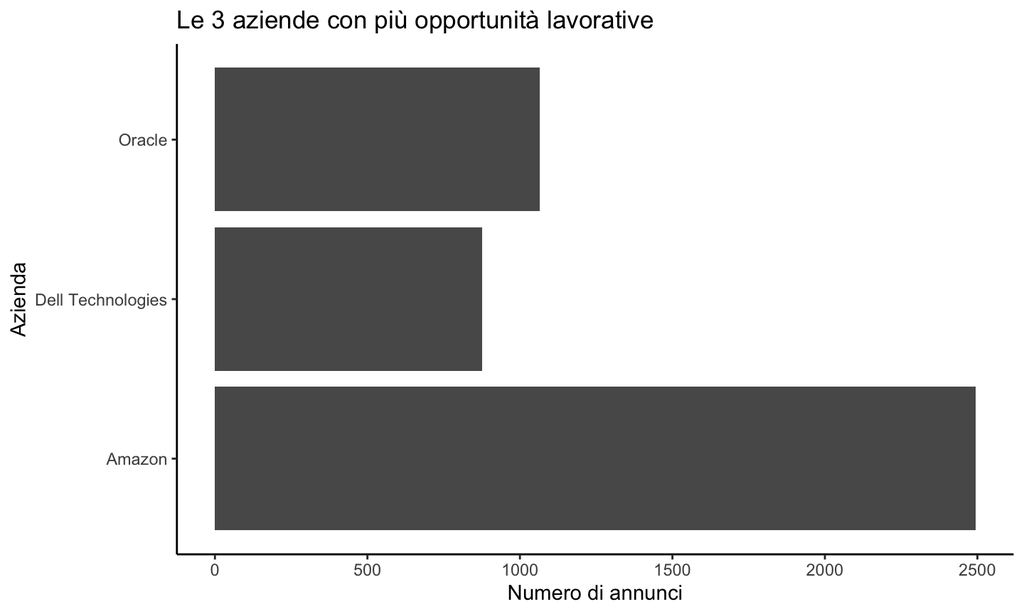

```r
most_employer_jobs <- jobs_listings %>%
  filter(!is.na(map.employerName) & !is.null(map.employerName)
  & map.employerName != "") %>%
  group_by(map.employerName) %>%
  dplyr::summarise(count = n(), .groups = 'drop') %>%

    arrange(desc(count)) %>%
  slice(1:3)

ggplot(most_employer_jobs, aes(x=map.employerName, y=count)) +
  geom_bar(stat = "identity") +
  geom_bar(stat = "identity") +
  labs(title = "Le 3 aziende con più opportunità lavorative",
       y="Numero di annunci", x= "Azienda") +
  coord_flip()
```

Amazon al primo posto, non l’avrei mai detto. Ma a me questa informazione sinceramente non mi aiuta molto nella mia carriera, si certo ora ho una conoscenza (per quanto banale) in più. Io voglio sapere quali sono le 3 aziende con più opportunità per la figura di: data analyst.

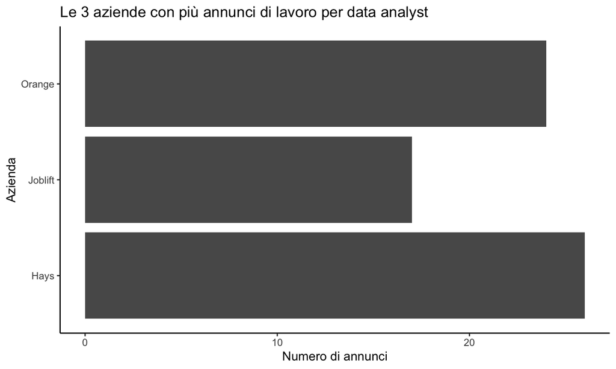

```r
companies_with_most_opportunities_for_da <- jobs_listings %>%
  filter(!is.na(map.employerName)
         & !is.null(map.employerName)
         & map.employerName != ""
         & str_detect(header.normalizedJobTitle, "data analyst")) %>%
  group_by(map.employerName) %>%
  dplyr::summarise(count = n(), .groups = 'drop') %>%
  arrange(desc(count)) %>%
  slice(1:3)

ggplot(companies_with_most_opportunities_for_da,
       aes(x=map.employerName, y=count)) +
  geom_bar(stat = "identity") +
  labs(
    title = "Le 3 aziende con più annunci di lavoro per data analyst",
       y="Numero di annunci", x= "Azienda") +
  coord_flip()
```

## Ora cerchiamo di essere curiosi, e vediamo dal 1900 ad oggi, qual’è stata la decade in cui sono nate più imprese.

Per farlo useremo la ricorsione, ma a voi questo non interessa, perciò mostriamo subito il grafico.

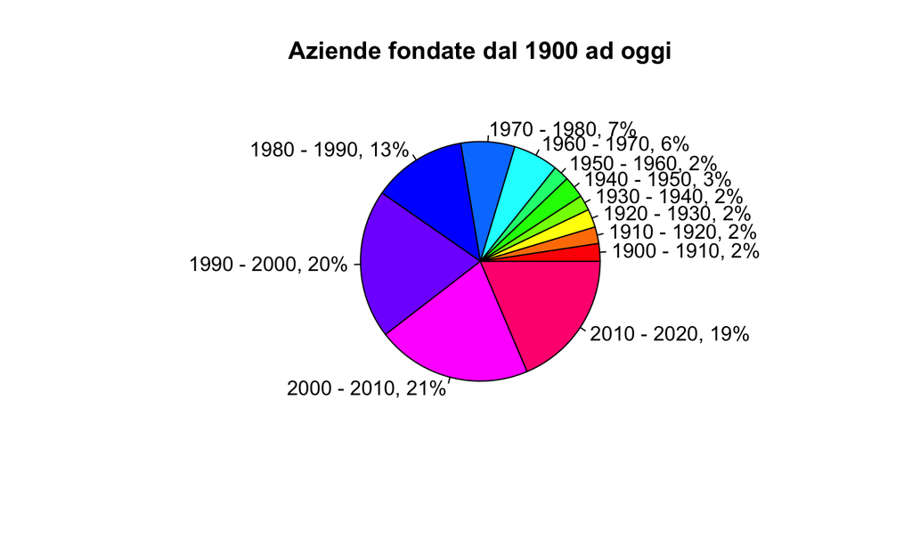

```r
years <- c(1899, 1909, 1919, 1929, 1939, 1949,
           1959, 1969, 1979, 1989, 1999, 2009, 2019)
manipulate_data <- function(frame, n)
{
  companies_foundation_year <- jobs_listings %>%
    filter(overview.foundedYear > years[n-1] &
             overview.foundedYear < (years[n] + 1)) %>%
    group_by(overview.foundedYear) %>%
    dplyr::summarise(count = n(), .groups = 'drop')
  total <- sum(companies_foundation_year$count)
  label <- paste((years[n-1]+1), (years[n]+1), sep = " - ")
  frame <- rbind(frame, data.frame(decade = label, count = total))
  if (length(years) > n){
    return(manipulate_data(frame, n+1))
  }
  return(frame)
}

result <- manipulate_data(data.frame(decade = c(), count = c()), 2)

pct <- round(result$count/sum(result$count)*100)
lbls <- paste(result$decade, pct, sep = ", ")
lbls <- paste(lbls,"%",sep="")
pie(result$count,labels = lbls, col=rainbow(length(lbls)),
    main="Aziende fondate dal 1900 ad oggi")
```

Quindi nella prima decade del 21° secolo è stata la decade che ha visto più imprese nascere. Ora, vediamo quali sono stati i settori più floridi in quegli anni.

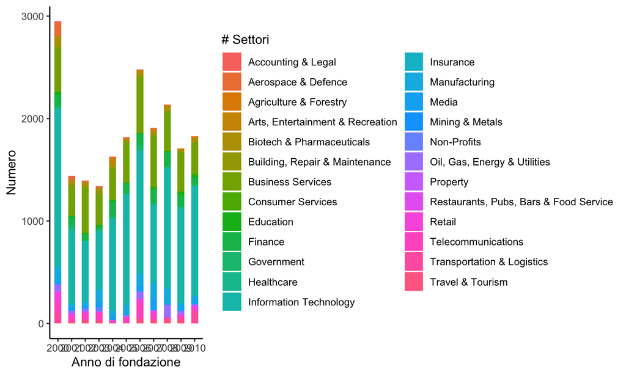

```r
companies_2000_2010 <- jobs_listings %>%
  filter(overview.foundedYear > 1999
         & overview.foundedYear <= 2010
         & overview.sector != "") %>%
  select(overview.sector, overview.foundedYear)

g <- ggplot(companies_2000_2010,
            aes(x = as.character(overview.foundedYear),
                fill = overview.sector))
g + geom_bar(aes(fill=overview.sector),
             width = 0.5) +
  labs(
    tititle="Settori di imprese fondate negli anni 2000-2010",
       x="Anno di fondazione",
       fill="# Settori",
       y="Numero")
```

Come si vede dal grafico, il settored dell IT (Information Technology), è stato quello più presente. A sto punto cerchiamo di capire la distribuzione geografica delle aziende operanti in questo settore.

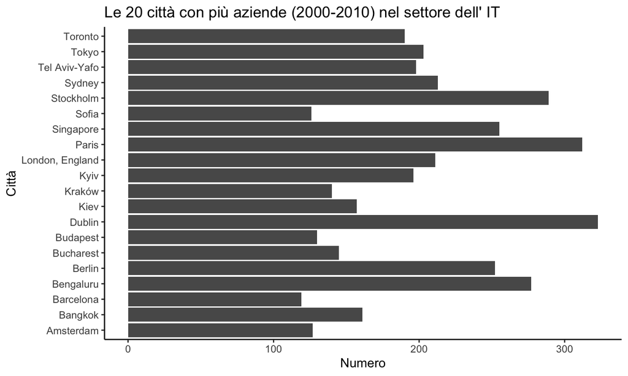

```r
jobs_for_it_companies <- jobs_listings %>%
  filter(overview.foundedYear > 1999 & overview.foundedYear <= 2010
         & overview.sector == "Information Technology") %>%
  group_by(header.location) %>%
  dplyr::summarise(count = n(), .groups = 'drop') %>%
  arrange(desc(count)) %>%
  slice(1:20)

ggplot(jobs_for_it_companies, aes(x=header.location, y=count)) +
  geom_bar(stat = "identity") +
  coord_flip() +
  labs(
    title="Le 20 città con più aziende (2000-2010) nel settore dell' IT",
       x="Città",
       y="Numero")
```

## La dimensione di un’azienda dipende dalla sua tipologia?

E’ interessante capire, se in base alla tipologia di azienda, mi ritroverò a fare una lunga coda o meno alla macchinetta del caffè.

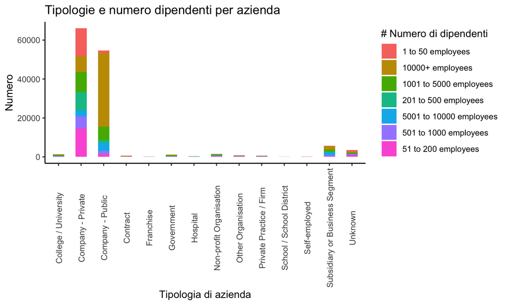

```r
type_of_company_for_sector <- jobs_listings %>%
  filter(overview.size != "" & overview.size != "Unknown"
         & overview.type != "" & overview.type != "") %>%
  select(overview.size, overview.type)

g <- ggplot(type_of_company_for_sector, aes(x = overview.type, fill = overview.size))
g + geom_bar(aes(fill=overview.size), width = 0.5) +
  theme(axis.text.x = element_text(angle=90, vjust=0.6)) +
  labs(title="Tipologie e numero dipendenti per azienda",
       x="Tipologia di azienda",
       fill="# Numero di dipendenti",
       y="Numero")
```

## Okok, ora abbiamo un idea del panorama mondiale, ma noi vogliamo lavorare come data analyst.

Inanzitutto, non si lavora per la gloria, dunque vediamo come sono i salari per settore per le figure di data analyst.

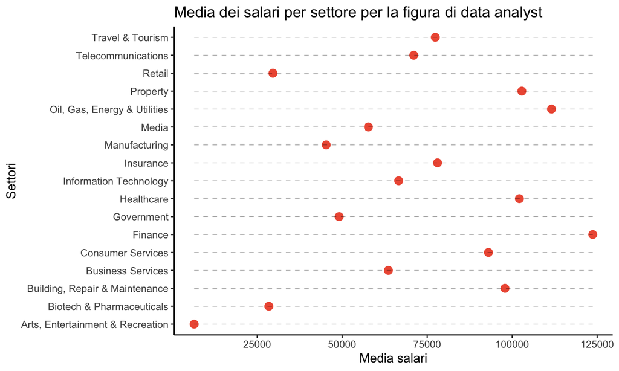

```r
jobs_uk_salaries <- jobs_listings %>%
  filter((map.country == "United Kingdom"
          | map.country == "Uk"
          | map.country == "England")
         & overview.sector != ""
         & salary.currency.name == "United Kingdom Pound"
         & str_detect(header.normalizedJobTitle, "data analyst") ) %>%
  select(overview.sector, salary.salaries)
jobs_uk_avg_salaries <- ddply(jobs_uk_salaries,
                              .(overview.sector),
                              summarize,
                              avg=mean(salary.salaries))

ggplot(jobs_uk_avg_salaries, aes(x=overview.sector, y=avg)) +
  geom_point(col="tomato2", size=3) +
  geom_segment(aes(x=overview.sector,
                   xend=overview.sector,
                   y=min(avg),
                   yend=max(avg)),
               linetype="dashed",
               size=0.1) +
  labs(
    title="Media dei salari per settore per la figura di data analyst",
       y = "Media salari", x= "Settori") +
  coord_flip()
```

Ok, quindi come scendiamo dall’aereo mandiamo il CV alle aziende nell’ambito della finanza. Immagino che potremmo chiudere qua l’analisi, ma sappiamo che a tutti noi interessano solo i soldi per apparire belli su instagram. Ma proviamo a capirci di più sul panorama inglese.

## Studiamo gli anni di fondazione delle aziende

Vediamo come si distribuiscono gli anni di fondazione delle aziende.

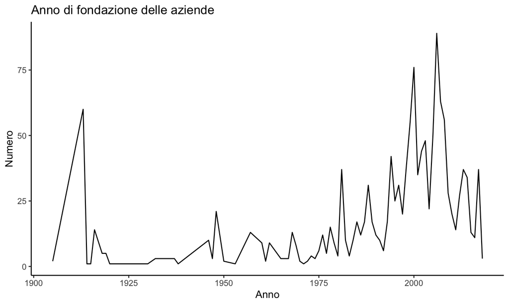

```r
companies_uk_foundation_year_over_1900 <- jobs_listings %>%
  filter((map.country == "United Kingdom" | map.country == "Uk" | map.country == "England") & overview.foundedYear > 1900) %>%
  group_by(overview.foundedYear) %>%
  dplyr::summarise(count = n(), .groups = 'drop')

ggplot(companies_uk_foundation_year_over_1900, aes(x=overview.foundedYear)) +
  geom_line(aes(y=count)) +
  labs(title="Anno di fondazione delle aziende",
       x="Anno",
       y="Numero")
```

```r
#Anno in cui sono state fondate più aziende
max_foundationyear <- companies_uk_foundation_year_over_1900 %>%
  slice(which.max(count))
```

Ok quindi il 2006 è l’anno con più aziende fondate, vediamo qual’era il settore di punta

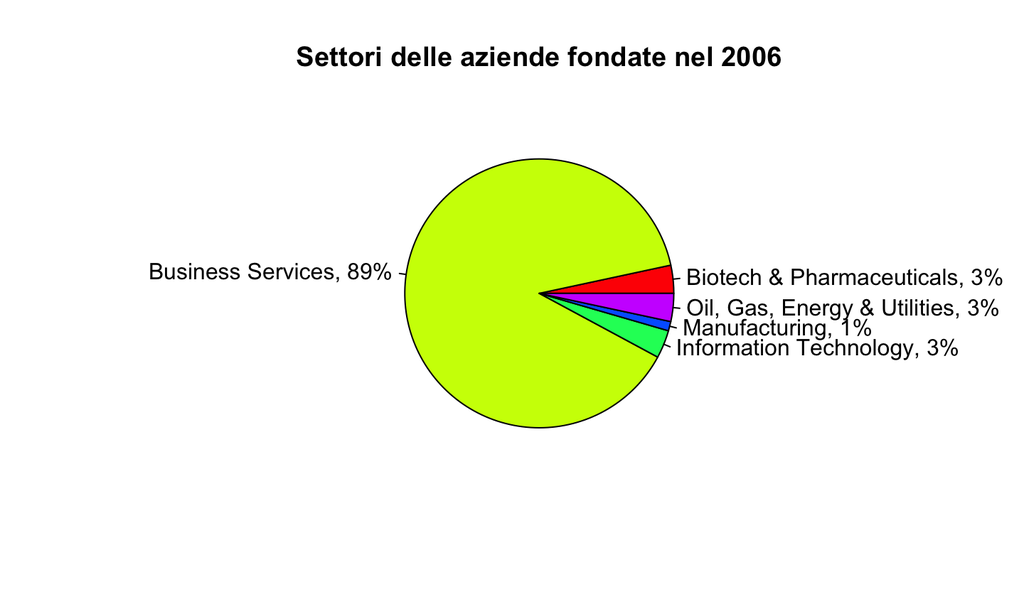

```r
sectors_companies_founded_2006 <- jobs_listings %>%
  filter((map.country == "United Kingdom"
          | map.country == "Uk"
          | map.country == "England")
         & overview.sector != ""
         & overview.foundedYear == 2006) %>%
  group_by(overview.sector) %>%
  dplyr::summarise(count = n(), .groups = 'drop')

pct <- round(sectors_companies_founded_2006$count/sum(sectors_companies_founded_2006$count)*100)
lbls <- paste(sectors_companies_founded_2006$overview.sector, pct, sep = ", ") # add percents to labels
lbls <- paste(lbls,"%",sep="") # ad % to labels
pie(sectors_companies_founded_2006$count,labels = lbls, col=rainbow(length(lbls)),
    main="Settori delle aziende fondate nel 2006")
```